# 15.071 Fall 2024: Assignment 2

Feature Engineering, Regularization, Logistic Regression

Donghang Li

Due: Oct 2, 2024

### Reminders:

- Enable visual mode for a better editing experience.
- You only need to add code where you see `### YOUR CODE HERE ###`. Often-times, you’ll see a `???` in the code, which you will need to replace.
- Replace the text *Your Answer Here* with your answer to the various questions.

### Load Libraries (Don’t Forget to Run This)

Let’s first load the necessary libraries. You will need to install the `pROC` package using `install.packages('pROC')` provided below. We forgot to include this one in the R installation instructions.

```r
library(caret)
library(glmnet)
library(dplyr)
library(pROC)
```

This assignment contains the following 3 questions. Problem 1 and 2 are about the Ames Housing dataset from Assignment 1.

- **Problem 1: Feature Engineering.** We perform feature engineering on the Ames Housing Dataset to capture non-linear relationships between the various independent variables and Sales Price (the dependent variable).
- **Problem 2: Regularization.** We demonstrate the power of regularization by intentionally adding in noise to our dataset so that linear regression (without regularization) grossly overfits. Then, we show that LASSO regularization allows us to remove most of the noisy terms and recover a model with much better out of sample performance.
- **Problem 3: Logistic Regression.** We use a logistic regression model to predict whether a patient will develop Coronary Heart Disease (CHD) using a dataset from the Framingham Heart Study.

# Problem 1: Feature Engineering [40 Points]

Let’s load the dataset `AmesSales_assignment2.csv` and remind ourselves what the features are. The code below prints out the names of the 11 independent variables as well as the dependent variable `SalePrice`.

```r
data = read.csv('AmesSales_assignment2.csv')
colnames(data)
```

```
 [1] "SalePrice"  "TotalRooms" "Bedrooms"   "FullBath"   "HalfBath"   "Fireplaces" "LivArea"
 [8] "GarageArea" "PoolArea"   "YearBuilt"  "YearSold"   "BldgType"
```

Let’s perform a test/train split and then train a baseline linear regression model. The code has been filled out for you below. Note that we chose a test/train split where `p=0.25`, meaning only 25% of our data is going into the training set, while 75% is going to our test set. This is **unconventional** and only done for educational purposes. Recall that a smaller training set makes models more prone to overfitting, which we will correct in the regularization portion of this assignment.

```r
set.seed(20)
trainIndex <- createDataPartition(data$SalePrice, p = 0.25, list = FALSE)
train_data <- data[trainIndex, ]
test_data <- data[-trainIndex, ]

dim(train_data)
```

```
[1] 708  12
```

```r
model = lm(SalePrice ~ ., data=train_data)
summary(model)
```

```
Call:
lm(formula = SalePrice ~ ., data = train_data)

Residuals:
    Min      1Q  Median      3Q     Max
-374459  -19690    -669   16745  166897

Coefficients:
                 Estimate Std. Error t value Pr(>|t|)
(Intercept)     6.130e+05  2.253e+06   0.272   0.7856
TotalRooms     -1.639e+03  1.761e+03  -0.931   0.3523
Bedrooms       -5.477e+03  2.599e+03  -2.107   0.0355 *
FullBath        7.662e+03  4.016e+03   1.908   0.0568 .
HalfBath       -1.909e+04  3.708e+03  -5.148 3.43e-07 ***
Fireplaces      1.148e+04  2.567e+03   4.471 9.10e-06 ***
LivArea         9.549e+01  6.463e+00  14.773  < 2e-16 ***
GarageArea      6.498e+01  8.927e+00   7.279 9.16e-13 ***
PoolArea        4.280e+01  5.788e+01   0.739   0.4599
YearBuilt       8.933e+02  6.843e+01  13.055  < 2e-16 ***
YearSold       -1.174e+03  1.117e+03  -1.051   0.2935
BldgType2fmCon -8.201e+03  1.033e+04  -0.794   0.4276
BldgTypeDuplex -4.981e+04  8.701e+03  -5.724 1.55e-08 ***
BldgTypeTwnhs  -7.106e+03  7.095e+03  -1.002   0.3169
BldgTypeTwnhsE -1.367e+04  5.545e+03  -2.464   0.0140 *
---
Signif. codes:  0 ‘***’ 0.001 ‘**’ 0.01 ‘*’ 0.05 ‘.’ 0.1 ‘ ’ 1

Residual standard error: 37230 on 693 degrees of freedom
Multiple R-squared:  0.7617,    Adjusted R-squared:  0.7569
F-statistic: 158.2 on 14 and 693 DF,  p-value: < 2.2e-16
```

Let’s try to improve the R2 by analyzing a few of the variables.

## (a) Year Built [15 Points]

One of the significant variables above is Year Built. Let’s use the `plot` function to make a scatter plot between `YearBuilt` and `SalePrice`.

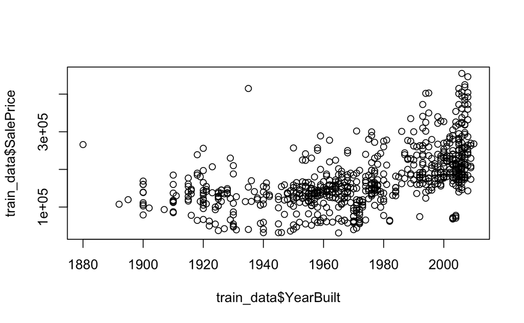

```r
plot(train_data$YearBuilt, train_data$SalePrice)
```

The relationship between Year Built and Sale Price looks non-linear. The data seems to have a gradual increase in the price up to 1970, after which there is a more prominent increase in price for properties built afterwards. Using this information, let’s add a feature `YearBuiltafter1970` so that our Linear Regression model can “bend” at 1970.

**Task.** Add to BOTH the training dataset and testing the feature `YearBuiltafter1970`, which should be equal to the number of years after 1970 (e.g., 2000 is 30 years after 1970), or 0 if the year is 1969 or earlier. You can do this using the `pmax` function.

Don’t forget to do this for both `train_data` AND `test_data`.

```r
### YOUR CODE HERE ###
train_data$YearBuiltafter1970 = pmax(train_data$YearBuilt - 1970, 0)
test_data$YearBuiltafter1970 = pmax(test_data$YearBuilt - 1970, 0)

### Code for showing the top 6 rows of the columns YearBulit and YearBuilt_after1970 ####
head(train_data[, c('YearBuilt', 'YearBuiltafter1970')])
```

|  | YearBuilt | YearBuiltafter1970 |
| --- | --- | --- |
| 4 | 1968 | 0 |
| 8 | 1992 | 22 |
| 9 | 1995 | 25 |
| 12 | 1992 | 22 |
| 21 | 1974 | 4 |
| 24 | 1971 | 1 |

Confirm from the code output above that your `YearBuiltafter1970` is correct.

Let’s create a new model `model2` using `train_data`, which now contains this extra variable.

```r
model2 = lm(SalePrice ~ . ,data=train_data)
summary(model2)
```

```
Call:
lm(formula = SalePrice ~ ., data = train_data)

Residuals:
    Min      1Q  Median      3Q     Max
-361346  -20484   -1008   18434  161462

Coefficients:
                     Estimate Std. Error t value Pr(>|t|)
(Intercept)         1.682e+06  2.231e+06   0.754   0.4512
TotalRooms         -2.593e+03  1.746e+03  -1.485   0.1380
Bedrooms           -2.104e+03  2.659e+03  -0.791   0.4290
FullBath            2.864e+03  4.085e+03   0.701   0.4835
HalfBath           -1.960e+04  3.654e+03  -5.362 1.12e-07 ***
Fireplaces          1.438e+04  2.603e+03   5.526 4.65e-08 ***
LivArea             9.130e+01  6.428e+00  14.204  < 2e-16 ***
GarageArea          6.263e+01  8.807e+00   7.112 2.87e-12 ***
PoolArea            4.812e+01  5.702e+01   0.844   0.3990
YearBuilt           5.340e+02  1.018e+02   5.246 2.06e-07 ***
YearSold           -1.355e+03  1.101e+03  -1.231   0.2187
BldgType2fmCon     -1.130e+04  1.020e+04  -1.108   0.2681
BldgTypeDuplex     -4.058e+04  8.792e+03  -4.616 4.67e-06 ***
BldgTypeTwnhs      -3.165e+03  7.039e+03  -0.450   0.6531
BldgTypeTwnhsE     -1.565e+04  5.479e+03  -2.857   0.0044 **
YearBuiltafter1970  9.797e+02  2.079e+02   4.712 2.96e-06 ***
---
Signif. codes:  0 ‘***’ 0.001 ‘**’ 0.01 ‘*’ 0.05 ‘.’ 0.1 ‘ ’ 1

Residual standard error: 36670 on 692 degrees of freedom
Multiple R-squared:  0.7691,    Adjusted R-squared:  0.7641
F-statistic: 153.7 on 15 and 692 DF,  p-value: < 2.2e-16
```

**Question 1.** The in-sample R2 increased from `model` to `model2`. Is this expected or surprising? Justify your answer.

**Answer 1.** *This is expected. First, because we are adding a feature, which means we are giving the model more information, so the fitting power is likely to increase. Also, this new variable is quite significant in model2, which means it helps fit the data in the training set better.*

**Question 2.** Interpret the coefficients of `YearBuilt` and `YearBuiltAfter1970`. Can you provide a real-world explanation for why there is a difference before/after 1970?

**Answer 2.** *The coefficient of YearBuilt means holding all other variables the same, each increased year is associated with an increase by $534 in housing value. The coefficient of YearBuiltAfter1970 means holding all other variables the same, each increased year after 1970 is associated with an additional increase by $979.7 in housing value. I think in real-world cases, the political-economy factor is innegligible in this phenomenon. After 1970, the world was experiencing a period of high inflation, leading to a fast growth in housing price. Additionally, in the 1990s, the economy in the United States is prosperous and the interest rate is low, which results in a rapid increase in housing value.*

## (b) Living Area [5 Points]

We hypothesize that there may be non-linear relationship between living area and price. Let’s visualize the data by breaking living area into 5 buckets based on quantiles, that is: the bottom 20% of properties by living area, 20%-40%, 40%-60%, 60%-80% and 80%-100%.

The code is provided for you below. `break_points` defines the 0, 20, 40, 60, 80 and 100th quantiles, while the function `cut` divides the `LivArea` variable into buckets based on `break_points`.

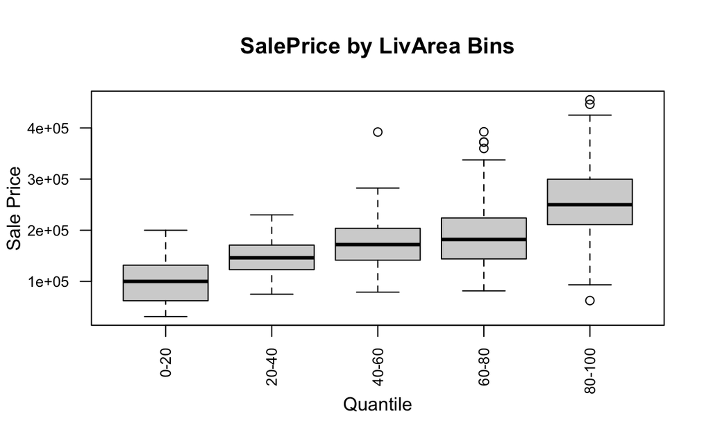

```r
train_data_dummy <- train_data

break_points <- quantile(train_data_dummy$LivArea, probs = seq(0, 1, 0.2))
train_data_dummy$LivArea_Bins <- cut(train_data_dummy$LivArea, breaks = break_points, labels=c('0-20', '20-40', '40-60', '60-80', '80-100'))

boxplot(SalePrice ~ LivArea_Bins, data = train_data_dummy,
        main = "SalePrice by LivArea Bins",
        xlab = "Quantile", ylab = "Sale Price",cex.axis = 0.8, # Adjusts axis label size
        las = 2)  # las = 2 rotates the x-axis labels
```

The thick black line in each box represents the median sale price of properties in that bucket. We notice a trend in the median of each bucket, where there seems to be 2 “bends”, one between 0-20 and 20-40 and another between 60-80 and 80-100. We choose to augment `LivArea` with higher order polynomial features of degree 2 and 3.

**Task.** Create the features `LivArea2` and `LivArea3` to both `train_data` as well as `test_data`. `LivArea2` should be `LivArea` raised to the 2nd power, while `LivArea3` is `LivArea` raised to the 3rd power.

Don’t forget to do this for both `train_data` AND `test_data`.

```r
### YOUR CODE HERE (add LivArea2, LivArea3 to train_data, test_data) ###
train_data$LivArea2 = train_data$LivArea^2
train_data$LivArea3 = train_data$LivArea^3

test_data$LivArea2 = test_data$LivArea^2
test_data$LivArea3 = test_data$LivArea^3

### Code below is provided for displaying the additional columns added
head(train_data[, c('LivArea', 'LivArea2', 'LivArea3')])
```

|  | LivArea | LivArea2 | LivArea3 |
| --- | --- | --- | --- |
| 4 | 2110 | 4452100 | 9393931000 |
| 8 | 1280 | 1638400 | 2097152000 |
| 9 | 1616 | 2611456 | 4220112896 |
| 12 | 1187 | 1408969 | 1672446203 |
| 21 | 1173 | 1375929 | 1613964717 |
| 24 | 1078 | 1162084 | 1252726552 |

Let’s train a model `model3` and calculate its R2.

```r
model3 = lm(SalePrice ~ . ,data=train_data)
summary(model3)
```

```
Call:
lm(formula = SalePrice ~ ., data = train_data)

Residuals:
   Min     1Q Median     3Q    Max
-91171 -20992  -1494  17418 158664

Coefficients:
                     Estimate Std. Error t value Pr(>|t|)
(Intercept)         1.162e+06  2.072e+06   0.561 0.575074
TotalRooms         -1.339e+03  1.631e+03  -0.821 0.411953
Bedrooms           -7.513e+03  2.523e+03  -2.977 0.003008 **
FullBath           -4.990e+03  3.883e+03  -1.285 0.199172
HalfBath           -2.373e+04  3.416e+03  -6.947 8.63e-12 ***
Fireplaces          1.089e+04  2.448e+03   4.447 1.01e-05 ***
LivArea             8.246e+01  3.195e+01   2.581 0.010065 *
GarageArea          6.242e+01  8.185e+00   7.626 8.02e-14 ***
PoolArea            5.187e+01  5.299e+01   0.979 0.327943
YearBuilt           6.621e+02  9.572e+01   6.917 1.05e-11 ***
YearSold           -1.223e+03  1.022e+03  -1.197 0.231763
BldgType2fmCon     -1.280e+04  9.472e+03  -1.351 0.177141
BldgTypeDuplex     -4.435e+04  8.177e+03  -5.424 8.05e-08 ***
BldgTypeTwnhs      -2.721e+02  6.552e+03  -0.042 0.966893
BldgTypeTwnhsE     -1.441e+04  5.089e+03  -2.832 0.004759 **
YearBuiltafter1970  6.952e+02  1.967e+02   3.534 0.000437 ***
LivArea2            3.477e-02  1.499e-02   2.320 0.020652 *
LivArea3           -9.571e-06  2.182e-06  -4.387 1.33e-05 ***
---
Signif. codes:  0 ‘***’ 0.001 ‘**’ 0.01 ‘*’ 0.05 ‘.’ 0.1 ‘ ’ 1

Residual standard error: 34050 on 690 degrees of freedom
Multiple R-squared:  0.8015,    Adjusted R-squared:  0.7966
F-statistic: 163.9 on 17 and 690 DF,  p-value: < 2.2e-16
```

**Question 3**. How does this R2 compare to that of `model2`? Would you say `LivArea2` and `LivArea3` are useful variables to add?

**Answer 3**: *The R2 of model3 increases from 0.7691 to 0.8015 compared to that of model2. I think the two variables are useful to add. First, they increase the fitting power (R2) of the data. Second, the two variables are both significant in the model. Third, from the boxplot we see that there is a non-linear relationship between LivArea and SalePrice. In all, the two variables are useful to add.*

## (c) Hypothetical Feature Engineering [15 Points]

In each of the following questions, we pose a hypothetical scenario and ask you a question related to feature engineering. Note that the observations are made up and do not necessarily hold in the real dataset.

**Question 4**. You examine how Sale Price changes with the number of fireplaces, a very significant variable in the regression model. You notice that homes with 0 fireplaces, 1 fireplace, 2 fireplaces and 3 fireplaces have an average sale price given in the table below. The relationship between fireplace and sale price is clearly non-linear..

| Number of Fireplaces | Average Sale Price |
| --- | --- |
| 0 | $100,000 |
| 1 | $200,000 |
| 2 | $500,000 |
| 3 | $1,000,000 |

**Using this information, propose 2 ways that you could help Linear Regression capture this non-linearity. (Hint: one of the ways is from Lecture 2)**

**Answer 4:** *First, we can convert this variable into 3 dummies, which correspond to having 1, 2, or 3 fireplaces. By replacing this variable with the three dummies, we are able to capture this non-linearity. Second, we can add* *higher order polynomial features of the fireplace variable in the model, like the quadratic or cubic form.*

**Question 5**.Your real-estate friend tells you a secret from the trade: there is a strong connection between Bedroom, Living Area and SalePrice. For properties with a small number of bedrooms, each additional square foot of living area has a large impact on the sale price of the unit. On the other hand, for properties with a larger number of bedrooms, the impact of each additional square foot of living area is much smaller.

**Using this information, propose a new feature to add to the dataset.**

**Answer 5:** *We can add the interaction term into the model. For example, we can multiply the variable bedroom with living area. By doing so, we make sure that the impact of each additional square foot of living area is dependent on the number of bedrooms.*

**Question 6.** While the dataset contains the variables for the number of full and half bathrooms, it is customary to simply include the total number of bathrooms as Full Bath + 0.5 * Half Bath. (e.g., a property with 2 full baths and 1 half bath is typically said to have 2.5 total bath). Your friend says you should add the feature `TotalBaths` to your dataset, equal to `FullBath` plus 0.5 times `HalfBath`. Your friend says that doing so will increase the in-sample R2.

**Do you agree or disagree with your friend? Why?**

**Answer 6.** *I disagree with my friend because it would lead to the multicollinearity problem. If doing so, the variable TotalBaths is highly correlated with both FullBath and HalfBath, which will lead to the biased estimation of the coefficient. Actually, since this new variable is a linear combination of the two variables, its coefficient can be decomposed into the sum of the coefficients of the other two coefficients. So there is no improvement.*

## (d) Calculating OSR<sup>2</sup> [5 Points]

Let’s test the out-of-sample performance of all 3 models. Code is provided below to display the results nicely in a table.

```r
calculate_r2 <- function(predictions) {
  return(1 - sum((predictions - train_data$SalePrice)^2) / sum((mean(train_data$SalePrice) - train_data$SalePrice)^2))
}

calculate_osr2 <- function(predictions) {
  return(1 - sum((predictions - test_data$SalePrice)^2) / sum((mean(train_data$SalePrice) - test_data$SalePrice)^2))
}

data.frame(
  name = c('model', 'model2', 'model3'),
  r2 = c(
    calculate_r2(predict(model, newdata=train_data)),
    calculate_r2(predict(model2, newdata=train_data)),
    calculate_r2(predict(model3, newdata=train_data))),
  osr2 = c(
    calculate_osr2(predict(model, newdata=test_data)),
    calculate_osr2(predict(model2, newdata=test_data)),
    calculate_osr2(predict(model3, newdata=test_data))
  )
)
```

| name | r2 | osr2 |
| --- | --- | --- |
| model | 0.7616926 | 0.7473110 |
| model2 | 0.7691020 | 0.7593824 |
| model3 | 0.8015080 | 0.7733076 |

**Question 7**. Comment on the R<sup>2</sup> and OSR<sup>2</sup> performance above. Would you say our feature engineering was successful?

**Answer 7**. *I would not say our feature engineering was fully successful. Although the feature engineering by adding additional features into the model increases both in-sample R2 and out-of-sample R2, the increase is rather small compared to that of no feature engineering.* *So we cannot say it is very successful. We may still have other feature engineering methods that can perform better.*

# Problem 2: Regularization [35 Points]

In this question, we showcase the power of regularization to remove features that are purely noise. To demonstrate this, we first inject an extra 100 (!!) columns into `train_data` and `test_data`, each of which will be a uniform random number between 0 and 1. Clearly, these variables have nothing to do with SalePrice and are purely noise added for the sake of instruction. We will see how LASSO is able to remove this noise and recover the strong OSR2 we saw at the end of Question 1.

## (a) Adding the Noise [5 Points]

We add in 100 noisy features, called `noise_1`, `noise_2`, …, `noise_100` to our dataset. Our training dataset now has 115 features, the 1 dependent variable + 11 original variables + 3 variables we feature engineered + 100 features that are pure noise.

```r
set.seed(123)

n_noise <- 100  # Number of noise features to add
for (i in 1:n_noise) {
  train_data[[paste0("noise_", i)]] <- runif(nrow(train_data))
  test_data[[paste0("noise_", i)]] <- runif(nrow(test_data))
}

dim(train_data)
```

```
[1] 708 115
```

Let’s take a peek at a few columns of our dataset. We see that noise_1, noise_2 and noise_100 are just pure nonsense.

```r
head(train_data[, c('SalePrice', 'LivArea', 'Bedrooms', 'noise_1', 'noise_2', 'noise_100')])
```

|  | SalePrice | LivArea | Bedrooms | noise_1 | noise_2 | noise_100 |
| --- | --- | --- | --- | --- | --- | --- |
| 4 | 244000 | 2110 | 3 | 0.2875775 | 0.7899319 | 0.65403452 |
| 8 | 191500 | 1280 | 2 | 0.7883051 | 0.2156002 | 0.69097917 |
| 9 | 236500 | 1616 | 2 | 0.4089769 | 0.6207268 | 0.02475968 |
| 12 | 185000 | 1187 | 3 | 0.8830174 | 0.3777224 | 0.98042027 |
| 21 | 170000 | 1173 | 3 | 0.9404673 | 0.6040353 | 0.67642082 |
| 24 | 149900 | 1078 | 3 | 0.0455565 | 0.5645183 | 0.09286679 |

Let’s see how the in-sample performance of a linear regression model changes.

```r
options(max.print=200)
model_with_noise <- lm(SalePrice ~ .,data=train_data)
summary(model_with_noise)
```

```
Call:
lm(formula = SalePrice ~ ., data = train_data)

Residuals:
   Min     1Q Median     3Q    Max
-80415 -19941  -1320  17116 140336

Coefficients:
                     Estimate Std. Error t value Pr(>|t|)
(Intercept)         2.427e+06  2.263e+06   1.073 0.283844
TotalRooms         -1.814e+03  1.769e+03  -1.025 0.305755
Bedrooms           -5.447e+03  2.741e+03  -1.987 0.047363 *
FullBath           -5.564e+03  4.296e+03  -1.295 0.195806
HalfBath           -2.449e+04  3.711e+03  -6.599 9.21e-11 ***
Fireplaces          1.196e+04  2.666e+03   4.486 8.74e-06 ***
LivArea             9.064e+01  3.501e+01   2.589 0.009864 **
GarageArea          6.548e+01  8.963e+00   7.305 9.02e-13 ***
PoolArea            7.459e+01  5.795e+01   1.287 0.198515
YearBuilt           6.766e+02  1.049e+02   6.449 2.35e-10 ***
YearSold           -1.871e+03  1.117e+03  -1.675 0.094371 .
BldgType2fmCon     -1.313e+04  1.037e+04  -1.266 0.205918
BldgTypeDuplex     -4.614e+04  9.098e+03  -5.071 5.30e-07 ***
BldgTypeTwnhs       4.033e+03  7.216e+03   0.559 0.576483
BldgTypeTwnhsE     -9.394e+03  5.468e+03  -1.718 0.086321 .
YearBuiltafter1970  7.429e+02  2.117e+02   3.509 0.000483 ***
LivArea2            2.972e-02  1.645e-02   1.807 0.071344 .
LivArea3           -8.689e-06  2.395e-06  -3.628 0.000310 ***
noise_1             4.216e+03  4.911e+03   0.859 0.390949
noise_2            -6.325e+03  4.870e+03  -1.299 0.194553
noise_3             2.208e+03  5.004e+03   0.441 0.659271
noise_4            -1.649e+03  5.084e+03  -0.324 0.745839
noise_5             3.006e+03  4.831e+03   0.622 0.533977
noise_6            -4.893e+03  4.997e+03  -0.979 0.327821
noise_7             2.980e+03  4.890e+03   0.609 0.542562
noise_8            -2.272e+03  5.253e+03  -0.433 0.665512
noise_9             3.031e+03  4.813e+03   0.630 0.529069
noise_10           -3.823e+03  4.797e+03  -0.797 0.425820
noise_11            4.269e+03  4.946e+03   0.863 0.388427
noise_12           -2.592e+03  4.975e+03  -0.521 0.602547
noise_13            3.629e+03  4.860e+03   0.747 0.455486
noise_14           -6.288e+03  4.796e+03  -1.311 0.190320
noise_15           -1.977e+03  4.894e+03  -0.404 0.686358
noise_16           -5.320e+03  4.862e+03  -1.094 0.274294
noise_17           -2.354e+03  5.002e+03  -0.471 0.638010
noise_18            3.215e+03  4.779e+03   0.673 0.501440
noise_19           -4.893e+03  4.828e+03  -1.013 0.311241
noise_20            4.768e+03  4.920e+03   0.969 0.332893
noise_21            6.080e+03  5.079e+03   1.197 0.231771
noise_22           -8.495e+02  4.996e+03  -0.170 0.865040
 [ reached getOption("max.print") -- omitted 78 rows ]
---
Signif. codes:  0 ‘***’ 0.001 ‘**’ 0.01 ‘*’ 0.05 ‘.’ 0.1 ‘ ’ 1

Residual standard error: 34330 on 590 degrees of freedom
Multiple R-squared:  0.8275,    Adjusted R-squared:  0.7933
F-statistic: 24.19 on 117 and 590 DF,  p-value: < 2.2e-16
```

Note that not all variables are printed out in the summary above (“omitted 78 rows”).

Wow, the in-sample R<sup>2</sup> is pretty good! But what about the OSR<sup>2</sup>…

```r
calculate_osr2(predict(model_with_noise, test_data))
```

```
[1] 0.7371574
```

**Question 8.** Explain in your own words what overfitting means. Why does adding these 100 noise features lead to significant overfitting? What would you expect would happen if you added 1000 noise features instead?

**Answer 8.** *Overfitting means the pattern the model found in the training data does not apply to the data in test data, which means the generalization of the model is not good. From this perspective, these 100 noise features make the model learn what it should not learn, at the same time it is making the model more complex. By doing so, the model is trying to fit the random noise rather than the valuable information. Thus, when applying it to the test dataset, it performs rather bad, leading to the overfitting problem. I think the in-sample R2 will increase but the out-of-sample R2 will decrease when adding 1000 noise features instead compared to adding just 100 noise features. Because the model is getting way too complicated and learning a lot of garbage from the noise, resulting in a more severe overfitting problem.*

## (b) Regularization with Particular Lambda Values [15 Points]

We now use Linear Regression with LASSO regularization to build linear regression models that select a subset of these 115 variables. First, we process our data so that `X_train` and `X_test` only have the independent variables and `y_train` and `y_test` contain the dependent variable.

```r
X_train <- model.matrix(SalePrice ~ ., data = train_data)[,-1]
y_train <- train_data$SalePrice

X_test <- model.matrix(SalePrice ~ ., data = test_data)[,-1]
y_test <- test_data$SalePrice
```

**Task.** Build 3 LASSO models with $\lambda$ = 100, $\lambda$ = 3000 and $\lambda$ = 10,000 respectively.

```r
### YOUR CODE HERE ###
lasso_model_100 = glmnet(x = X_train, y = y_train, alpha = 1, lambda = 100)
lasso_model_3000 = glmnet(x = X_train, y = y_train, alpha = 1, lambda = 3000)
lasso_model_10000 = glmnet(x = X_train, y = y_train, alpha = 1, lambda = 10000)
```

We report the following metrics in the code provided below.

- In-Sample R2
- Out-of-Sample R2
- Number of non-zero coefficients (out of 115)

We also compare with `model_with_noise`, which is linear regression without regularization. This is equivalent to choosing $\lambda = 0$ in LASSO.

```r
results <- data.frame(
  model_name=c('No Regularization (Lambda = 0)', 'Lambda=100', 'Lambda=3000', 'Lambda=10000'),
  r2 = c(
    calculate_r2(predict(model_with_noise, train_data)),
    calculate_r2(predict(lasso_model_100, X_train)),
    calculate_r2(predict(lasso_model_3000, X_train)),
    calculate_r2(predict(lasso_model_10000, X_train))
  ),
  osr2 = c(
    calculate_osr2(predict(model_with_noise, test_data)),
    calculate_osr2(predict(lasso_model_100, X_test)),
    calculate_osr2(predict(lasso_model_3000, X_test)),
    calculate_osr2(predict(lasso_model_10000, X_test))
  ),
  non_zero_coefficients = c(
    ncol(train_data),
    sum(coef(lasso_model_100) != 0) - 1,
    sum(coef(lasso_model_3000) != 0) - 1,
    sum(coef(lasso_model_10000) != 0) - 1
  )
)

results
```

| model_name | r2 | osr2 | non_zero_coefficients |
| --- | --- | --- | --- |
| No Regularization (Lambda = 0) | 0.8275012 | 0.7371574 | 115 |
| Lambda=100 | 0.8262855 | 0.7431543 | 109 |
| Lambda=3000 | 0.7580922 | 0.7631702 | 10 |
| Lambda=10000 | 0.7087452 | 0.7195577 | 5 |

**Question 9.** In your own words, explain why a larger choice of lambda leads to a Linear Regression model with fewer non-zero coefficients (i.e., fewer variables selected)

**Answer 9.** *Because by choosing a larger lambda you are actually adding an extra penalty for large coefficients and increasing the weight of reducing model complexity in the loss function. You are expecting more variables with a zero coefficient by telling the model to not to involve those insignificant variables. Therefore, it leads to a feature selection.*

**Question 10.** Are there signs of overfiting or underfitting in the table above?

**Answer 10.** *I think the no regularization model and the model with lambda equals to 100 have the overfitting problem, reflected by OSR2 is much lower than in-sample R2. However, the model with lambda equals to 10000 may face the underfitting problem, with both R2 and OSR2 relatively lower than other models. This may originate from the model is excluding too many variables and getting too simple.*

## (c) Cross Validation to Find the Optimal Lambda [15 Points]

Use cross-validation from `cv.glmnet` to choose the optimal value of Lambda. Here, use 5-fold cross validation on values of lambda from 1000 to 10000 in increments of 200 (i.e., `seq(1000, 10000, 200)`). Print out the best value of lambda using `lasso_cv$lambda.min`.

```r
set.seed(0)

### YOUR CODE HERE (print out lasso_cv$lambda.min) ###
lambda.list = c(seq(1000, 10000, 200))
lasso_cv <- cv.glmnet(X_train, y_train, alpha=1, lambda=lambda.list, nfolds=5)
lasso_cv$lambda.min
```

```
[1] 2000
```

Construct a LASSO model called `lasso_model_optimal` using the optimal value of lambda you got above.

```r
### YOUR CODE HERE ###
lasso_model_optimal = glmnet(x = X_train, y = y_train, alpha = 1, lambda = 2000)

### The code below generates metrics for lasso_model_optimal ###
results_new <- data.frame(
  model_name='Lambda Optimal',
  r2 = calculate_r2(predict(lasso_model_optimal, X_train)),
  osr2 = calculate_osr2(predict(lasso_model_optimal, X_test)),
  non_zero_coefficients = sum(coef(lasso_model_optimal) != 0) - 1
)

rbind(results, results_new)
```

| model_name | r2 | osr2 | non_zero_coefficients |
| --- | --- | --- | --- |
| No Regularization (Lambda = 0) | 0.8275012 | 0.7371574 | 115 |
| Lambda=100 | 0.8262855 | 0.7431543 | 109 |
| Lambda=3000 | 0.7580922 | 0.7631702 | 10 |
| Lambda=10000 | 0.7087452 | 0.7195577 | 5 |
| Lambda Optimal | 0.7816085 | 0.7715487 | 24 |

**Question 11.** Comment on the performance of **`lasso_model_optimal`** shown in the “Lambda Optimal” row above.

**Answer 11.** *The performance of lasso_model_optimal shows no evidence of both underfitting and overfitting. First, when looking at the in-sample R2, this value is rather high with being close to 0.8, which is just slightly lower than the no regularization model. Second, the OSR2 of this optimal model is the highest among all these presented models, which shows the model plays a good role in prediction. Finally, the OSR2 is quite close to R2 without a significant decrease, indicating that the model has a good capability of generalization.*

Examine the coefficients of the optimal model by running the code below.

**Question 12:** Out of the 100 pure noise variables that we added, how many does this optimal LASSO model assign a non-zero coefficient to? Comment on how this highlights the ability for LASSO to remove insignificant variables.

**Answer 12.** *There are 14 noise variables assigned a non-zero coefficient by the LASSO model. We already know that these variables are pure noise that shouldn’t be included in the model before we start the regression, however, in real world cases we do not have prior knowledge about which variables are pure noises. So this highlights the importance of LASSO, which successfully removed over 85 percent of the noise variables in our case. We can apply it in real world analytics cases to rule out those insignificant noise variables.*

```r
coef(lasso_model_optimal)
```

```
118 x 1 sparse Matrix of class "dgCMatrix"
                              s0
(Intercept)        -8.833693e+05
TotalRooms          .
Bedrooms            .
FullBath            .
HalfBath           -1.151696e+04
Fireplaces          1.335911e+04
LivArea             9.487082e+01
GarageArea          6.933658e+01
PoolArea            .
YearBuilt           4.678472e+02
YearSold           -2.371102e+01
BldgType2fmCon     -6.656862e+02
BldgTypeDuplex     -3.336724e+04
BldgTypeTwnhs       .
BldgTypeTwnhsE      .
YearBuiltafter1970  9.183218e+02
LivArea2            .
LivArea3           -1.567983e-06
noise_1             .
noise_2             .
noise_3             .
noise_4             .
noise_5             .
noise_6             .
noise_7             .
noise_8             .
noise_9             .
noise_10            .
noise_11            .
noise_12            .
noise_13            .
noise_14           -2.162520e+03
noise_15            .
noise_16            .
noise_17            .
noise_18            .
noise_19           -2.429868e+03
noise_20            .
```

[output cut: 65 more lines]

```
noise_86            .
noise_87            .
noise_88            .
noise_89            .
noise_90            .
noise_91            .
noise_92            .
noise_93           -1.357244e+03
noise_94            4.940098e+03
noise_95            .
noise_96            .
noise_97            1.039511e+03
noise_98            .
noise_99            .
noise_100           .
```

# Problem 3: Logistic Regression for the Framingham Heart Study [55 Points]

Heart disease is the leading cause of death worldwide. About 15.5 million people died from coronary heart disease (CHD) in 2022—over 22% of all deaths that year across the globe (including COVID).

In the late 1940s, the U.S. government started to take various actions to address heart disease. As part of this effort, they decided to track a large cohort of initially healthy people over time. The town of Framingham, MA, was selected as the site for the study, which began in 1948 with 5,209 participants. Participants were given a questionnaire and a medical exam every two years, with data collected on physical and behavioral characteristics. Over the years, the study has expanded to include multiple generations and many factors, including genetic information. This dataset is now famously known as the Framingham Heart Study.

The dataset is contained in the file `framingham.csv`, with 3,658 observations corresponding to study participants. There are 16 variables in the dataset, described in Table 1. You aim to predict `tenYearCHD`, whether a patient experiences CHD within 10 years of their first examination. You will also aim to identify risk factors to make recommendations for preventing CHD.

**Table 1:** Variables in the dataset `framingham.csv`

| Variable | Description |
| --- | --- |
| male | Gender of patient (1 if male, 0 if female) |
| age | Age (in years) at first examination |
| education | Some high school, high school/GED, some college/vocational school, college |
| currentSmoker | 1 if patient is a current smoker, 0 otherwise |
| cigsPerDay | Number of cigarettes per day |
| BPMeds | 1 if patient is on blood pressure medication at time of first examination |
| prevalentStroke | 1 if patient previously had a stroke, 0 otherwise |
| prevalentHyp | 1 if patient is currently hypertensive, 0 otherwise |
| diabetes | 1 if patient currently has diabetes, 0 otherwise |
| totChol | Total cholesterol (mg/dL) |
| sysBP | Systolic blood pressure |
| diaBP | Diastolic blood pressure |
| BMI | Body Mass Index: weight (kg)/height (m)^2 |
| heartRate | Heart rate (beats/minute) |
| glucose | Blood glucose level (mg/dL) |
| tenYearCHD | 1 if patient has experienced coronary heart disease within 10 years, 0 otherwise |

Let’s read in the dataset.

```r
data <- read.csv("framingham.csv")
head(data)
```

|  | male | age | education | currentSmoker | cigsPerDay | BPMeds | prevalentStroke | prevalentHyp | diabetes | totChol | sysBP | diaBP | BMI | heartRate | glucose | TenYearCHD |
| --- | --- | --- | --- | --- | --- | --- | --- | --- | --- | --- | --- | --- | --- | --- | --- | --- |
| 1 | 1 | 39 | College | 0 | 0 | 0 | 0 | 0 | 0 | 195 | 106.0 | 70 | 26.97 | 80 | 77 | 0 |
| 2 | 0 | 46 | High school/GED | 0 | 0 | 0 | 0 | 0 | 0 | 250 | 121.0 | 81 | 28.73 | 95 | 76 | 0 |
| 3 | 1 | 48 | Some high school | 1 | 20 | 0 | 0 | 0 | 0 | 245 | 127.5 | 80 | 25.34 | 75 | 70 | 0 |
| 4 | 0 | 61 | Some college/vocational school | 1 | 30 | 0 | 0 | 1 | 0 | 225 | 150.0 | 95 | 28.58 | 65 | 103 | 1 |
| 5 | 0 | 46 | Some college/vocational school | 1 | 23 | 0 | 0 | 0 | 0 | 285 | 130.0 | 84 | 23.10 | 85 | 85 | 0 |
| 6 | 0 | 43 | High school/GED | 0 | 0 | 0 | 0 | 1 | 0 | 228 | 180.0 | 110 | 30.30 | 77 | 99 | 0 |

The dataset is imbalanced: only 15% of patients experienced CHD within 10 years.

```r
mean(data$TenYearCHD)
```

```
[1] 0.152269
```

Let’s create a train/test split with 75% in train and 25% in test.

```r
set.seed(1)

idx = createDataPartition(data$TenYearCHD, p=0.75, list=FALSE)
train <- data[idx,]
test = data[-idx,]

dim(train)
```

```
[1] 2744   16
```

## (a): Construct a logistic regression model [5 Points]

Using all the independent variables in the dataset, construct a logistic regression model to predict the probability that a patient will experience CHD within the next 10 years. Use the `glm` function with `family='binomial'`.

```r
### YOUR CODE HERE ###
model = glm(TenYearCHD ~., data=train, family="binomial")
summary(model)
```

```
Call:
glm(formula = TenYearCHD ~ ., family = "binomial", data = train)

Coefficients:
                                         Estimate Std. Error z value Pr(>|z|)
(Intercept)                             -8.216514   0.830001  -9.899  < 2e-16 ***
male                                     0.428965   0.127671   3.360  0.00078 ***
age                                      0.060780   0.007827   7.766 8.11e-15 ***
educationHigh school/GED                 0.007256   0.212050   0.034  0.97270
educationSome college/vocational school  0.019863   0.234459   0.085  0.93249
educationSome high school                0.205859   0.196665   1.047  0.29522
currentSmoker                            0.089382   0.182905   0.489  0.62507
cigsPerDay                               0.021160   0.007383   2.866  0.00416 **
BPMeds                                   0.039907   0.288250   0.138  0.88989
prevalentStroke                          0.531650   0.596311   0.892  0.37263
prevalentHyp                             0.199027   0.159347   1.249  0.21166
diabetes                                 0.557210   0.359831   1.549  0.12149
totChol                                  0.003086   0.001299   2.376  0.01752 *
sysBP                                    0.013174   0.004561   2.888  0.00387 **
diaBP                                   -0.001558   0.007660  -0.203  0.83884
BMI                                      0.014969   0.014685   1.019  0.30807
heartRate                               -0.005952   0.004923  -1.209  0.22667
glucose                                  0.004121   0.002826   1.458  0.14474
---
Signif. codes:  0 ‘***’ 0.001 ‘**’ 0.01 ‘*’ 0.05 ‘.’ 0.1 ‘ ’ 1

(Dispersion parameter for binomial family taken to be 1)

    Null deviance: 2321.2  on 2743  degrees of freedom
Residual deviance: 2066.7  on 2726  degrees of freedom
AIC: 2102.7

Number of Fisher Scoring iterations: 5
```

**Question 13.** Suppose that a patient could choose between (1) reducing their cigarettes per day (`cigsPerDay`) by 10 or reducing their systolic blood pressure `sysBP` by 10. According to the logistic regression model, which would lower that patient’s risk of CHD more?

**Answer 13.** *According to the logistic regression model, reducing cigarettes per day by 10 would lower the risk of CHD more. According to the setting of Logistic Regression, a variable with a higher coefficient will have a higher impact on the dependent variable for each unit change. The coefficient of cigsPerDay is 0.021160, which outnumbers the effect of reducing systolic blood pressure. Thus, holding the treatment intensity the same (by 10), reducing cigarettes will lower the risk more.*

## (b): Prediction for the fourth patient [5 Points]

```r
### YOUR CODE HERE ###
pred = predict(model, newdata=data[4,], type="response")
pred
```

```
       4
0.359389
```

The fourth patient is recommended by his doctor to curtail his smoking habits. Let’s calculate the predicted probability of CHD for a patient with the same characteristics as patient four, but who smokes only 20 cigarettes a day instead of 30? To do this in R, we create a copy of the 4th patient. Then, we update their `cigsPerDay` to 20. Then, run the same code as you did in the cell above on `fourth_patient_copy`.

```r
fourth_patient_copy = data[4,]
fourth_patient_copy$cigsPerDay[1] <- 20

### YOUR CODE HERE ###
pred = predict(model, newdata=fourth_patient_copy, type="response")
pred
```

```
        4
0.3122508
```

## (c): ROC and AUC [5 Points]

Generate probability predictions for all of the observations in the test set using our logistic regression models. Plot the test set ROC, and compute the AUC.

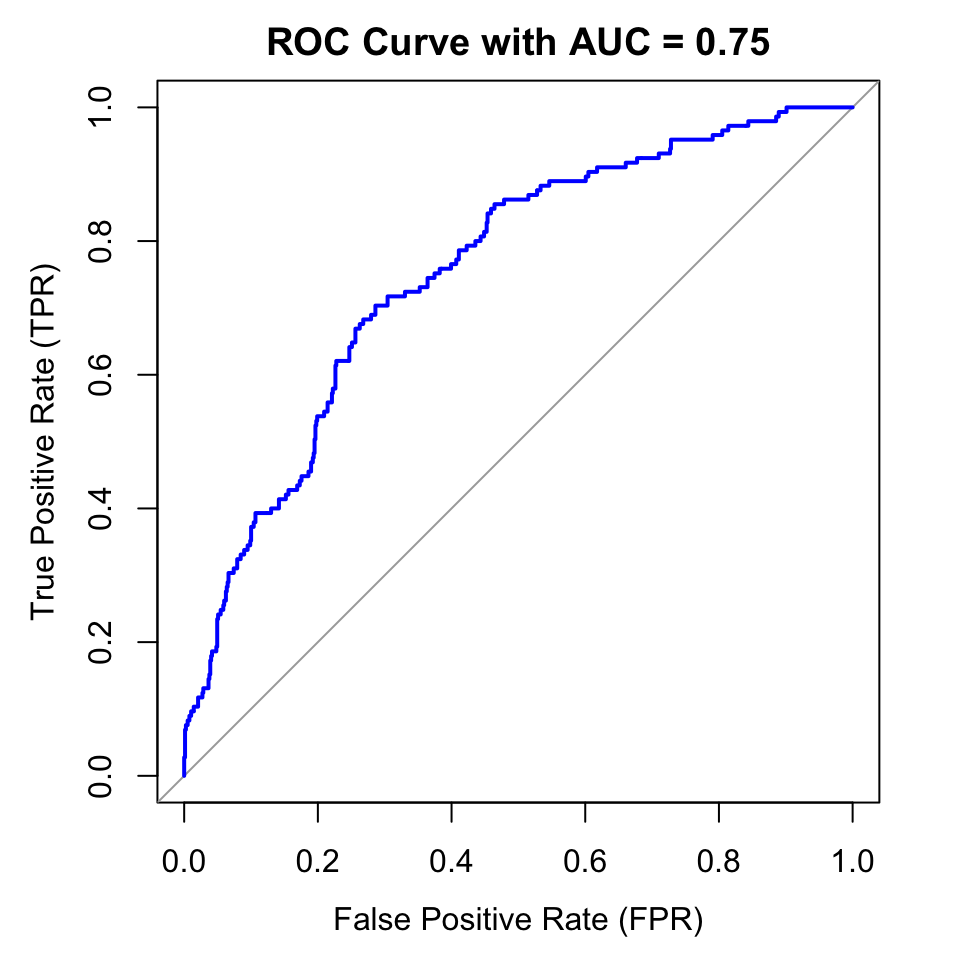

```r
### YOUR CODE HERE ###
test_predictions <- predict(model, newdata=test, type="response")

## Code for plotting and showing AUC ###
roc_curve <- roc(test$TenYearCHD, test_predictions)
auc_value <- auc(roc_curve)

plot(roc_curve,
     main = paste("ROC Curve with AUC =", round(auc_value, 2)),
     col = "blue",
     lwd = 2,
     xlab='False Positive Rate (FPR)',
     ylab='True Positive Rate (TPR)',
     xlim=c(1, 0),
     asp = NA ,
     legacy.axes = TRUE)
```

**Question 14.** Suppose I chose a probability threshold of 0.25 for predicting that a patient will develop CHD in the next 10 years. The false positive rate of my predictions is 13.9%. What is my true positive rate? (approximately, from the AUC curve graph).

**Answer 14.** *According to the AUC curve graph, the true positive rate corresponding to the specific false positive rate is about 40%.*

**Question 15.** If I were to decrease my threshold of predicting that a patient will develop CHD from 0.25 to 0.15, how would I expect the false positive rate and true positive rate to change? (increase/decrease)

**Answer 15.** *By doing so you’re predicting more patients who will develop CHD.You would expect both the false positive rate and true positive rate to increase.*

## (d) Prescribing Medication [10 Points]

To lower the risk of CHD, physicians can prescribe preventive medication that lowers blood pressure or cholesterol. Recommending preventive medications requires evidence-based analysis that weighs the pros and cons of such interventions. A common methodology is known as health economic evaluation, which accounts for medical costs and health benefits (a monetized metric of improved life longevity).

Let us suppose that a colleague of yours has just completed a health economics study to assess a recently approved medication. The study has estimated that patients who experience CHD within the next 10 years are expected to incur a lifetime cost of $150,000 associated with the disease—including the costs of treatment ($75,000) and lower quality of life and life expectancy ($75,000). The medicine is expected to lower patients’ risk of developing CHD within the next 10 years by a factor of 3. Regardless of whether a patient develops CHD, the preventive medication costs $9,000 (per patient) over the next 10 years. A table describing the study’s analysis is shown in Table 2, where p denotes the probability that a patient will develop CHD within the next 10 years without medication.

| Decision | Outcome | Probability | Cost |
| --- | --- | --- | --- |
| No medication | CHD | $p$ | $150,000 |
| No medication | No CHD | $1-p$ | $0 |
| Prescribe medication | CHD | $p/3$ | $159,000 |
| Prescribe medication | No CHD | $1-p/3$ | $9,000 |

**Question 15.** What is the expected cost for a patient who does not take the preventive medication, as a function of p? And what is the expected cost for a patient who is prescribed the preventive medication, as a function of $p$? For which values of $p$ would you recommend the medication (considering cost alone)?

**Answer 15.** *For those who do not take the preventive medication, the expected cost function is 150000p. For those who are prescribed, the expected cost function is 50000p+9000. I would recommend the medication if the expected cost is lower than that without medication, which leads to p is greater than 0.09.*

## (e) Predicting Who to Prescribe Medication To [20 Points]

Let’s use the threshold $p$ computed above to decide who to prescribe medication to. We decide to give the medication to patients with a predicted probability of CHD in 10 years higher than $p$. Recall from part (c) that we stored these predictions probabilities in a variable called `test_predictions`.

**Task.** Apply this threshold $p$ to `test_predictions` and generate `medication`, which contains TRUE if a patient will be prescribed the medicine and FALSE otherwise. Then, print out a confusion matrix, showing whether the patients we decide to treat will actually get CHD.

```r
### YOUR CODE HERE ###
medication <- test_predictions > 0.09

### Show the confusion matrix ###
confusion.matrix = table(test$TenYearCHD, medication)
confusion.matrix
```

```
   medication
    FALSE TRUE
  0   338  431
  1    16  129
```

Note that in this confusion matrix, the rows indicate whether the patient actually got CHD, while the columns represent whether we decide to give them medication.

**Question 16.** From the confusion matrix above, what is the accuracy, true positive rate and false positive rate of our medication decision? You can compute these using a calculator, or by running some simple computations in the R console.

```r
accuracy = sum(diag(confusion.matrix)) / sum(confusion.matrix)
accuracy
```

```
[1] 0.5109409
```

```r
truePos = confusion.matrix[2,2]/sum(confusion.matrix[2,])
truePos
```

```
[1] 0.8896552
```

```r
falsePos = confusion.matrix[1,2]/sum(confusion.matrix[1,])
falsePos
```

```
[1] 0.5604681
```

**Answer 16.** *The accuracy is 0.5109. The true positive rate is 0.8897. The false positive rate is 0.5605.*

**Question 17.** Comment on the interpretation of false positives and false negatives in our medication decision. As a medical practitioner deciding who to prescribe medicine to, which of these two quantities would you recommend to focus on minimizing?

**Answer 17.** *The false positives mean they do not have a CHD but we predict that they will. The false negatives have the opposite meanings, that they do have a CHD but we predict they wouldn’t. Both of the predictions are wrong, but the false negatives lead to a much more cost. Because the cost of having CHD ($150000) is much higher than that of preventive medication ($9000). So I would recommend to focus on minimizing the false negatives.*

From question 16, we see that the accuracy of our medical decisions is somewhat low. In fact, simply deciding to give *no one* the medication has an accuracy of about 84% (i.e., the proportion of people in our dataset who do not get CHD). However, our model achieved a pretty good AUC, showing that our model certainly has predictive power much higher than a model that randomly guesses.

**Question 18.** Using this observation, comment briefly on whether AUC or accuracy is a better metric in imbalanced datasets.

**Answer 18**. *I think in imbalanced datasets, AUC is generally a better metric than accuracy. Accuracy can be misleading in imbalanced datasets because it tends to be biased toward the majority class. In the abovementioned case, the accuracy is rather high but it wouldn’t provide any valuable insights. However, AUC takes into account both true positive and false positive rates, providing a more comprehensive measure of a model’s performance across different threshold settings, even in imbalanced datasets it can also perform good.*

## (h) Economic Cost Comparison [10 Points]

Let’s consider two scenarios regarding the 914 patients in the test set. Assume that *none* of the 914 patients in the test were given the CHD medication, and `test$TenYearCHD` is their CHD outcome in 10 years. From our data, we see that 145 out of 914 patients got CHD, leading to an economic cost of 145 * $150,000 = $21,750,000.

Let’s consider the following alternative scenarios.

- **Scenario 1:** Everyone in the test set is prescribed the medication. A patient who would have gotten CHD has a 2/3 chance of not getting CHD anymore, given the medication. A patient who would not have gotten CHD would obviously still not get CHD.
- **Scenario 2:** The patients with a probability of CHD higher than $p$ is given the medication (as indicated by `medication`). Similar to Scenario 1, assume that if a patient would have gotten CHD without the medicine, then have a 2/3 chance of not getting CHD anymore, given the medication.

**Question 19.** What is the total economic cost in Scenario 1?

```r
Total_cost_scenario1 = 914 * 9000 + 145 * 150000 * 1/3
Total_cost_scenario1
```

```
[1] 15476000
```

**Answer 19.** *The total cost in Scenario 1 is* $15,476,000.

**Question 20.** What is the expected total economic cost in Scenario 2? By comparing this cost to that of scenario 1 and the $23,796 per patient from doing nothing, comment on the value of our predictive medication model.

```r
Total_cost_scenario2 = truePos * 145 * 9000 + falsePos * (914-145) * 9000 + truePos * 145 * 150000 * 1/3 + (1-truePos) * 145 * 150000
Total_cost_scenario2
```

```
[1] 13890000
```

**Answer 20.** *According to the presented calculation results, the expected total economic cost in Scenario 2 is $13,890,000, which is lower than that in both scenario 1 and doing nothing. Our model significantly reduces the total cost by providing a more precise prediction. By only giving preventive medications to those who are most likely to have a CHD, we try to minimize the social cost.*